# COVID-19 US Forecast Evaluation Report

This report was developed by the [Reich Lab](https://reichlab.io/) and the US [COVID-19 Forecast Hub](https://covid19forecasthub.org/) from UMass-Amherst in collaboration with [CMU Delphi](https://delphi.cmu.edu/), as part of the Forecast Evaluation Research Collaborative.

August 09, 2021

# Overview

This report provides an evaluation of the accuracy and precision of probabilistic forecasts of COVID-19 cases and deaths submitted to the [US COVID-19 Forecast Hub](https://covid19forecasthub.org/). Some analyses include forecasts submitted in the past six months, starting in February 13, 2021. Others focus on evaluating “recent” forecasts, submitted only in the last 10 weeks.

In collaboration with the US Centers for Disease Control and Prevention (CDC), the COVID-19 Forecast hub collects short-term COVID-19 forecasts from dozens of research groups around the globe. Every week we combine the most recent forecasts from each team into a single “ensemble” forecast for each of the targets. This forecast is used as the official ensemble forecast of the CDC, typically appearing on their [forecasting website](https://www.cdc.gov/coronavirus/2019-ncov/covid-data/mathematical-modeling.html) on Wednesday. You can explore the full set of models, including their forecasts for past weeks online at CDC’s [interactive forecast visualization](https://covid.cdc.gov/covid-data-tracker/#forecasting_weeklydeaths/). Other related resources include CMU Delphi’s [forecast evaluation dashboard](https://delphi.cmu.edu/forecast-eval/), a separate product of the forecast Evaluation Research Collaborative, as well as the preprint [Evaluation of individual and ensemble probabilistic forecasts of COVID-19 mortality in the US.](https://www.medrxiv.org/content/10.1101/2021.02.03.21250974v2)

This report evaluates forecasts at the state and national level for newly reported weekly cases and deaths due to COVID-19. Data from the [JHU CSSE dashboard](https://coronavirus.jhu.edu/) is used as ground truth data for evaluating the forecasts.

# Incident Case Forecasts

## Summary Tables

The first table evaluates models based on their [adjusted relative weighted interval scores (WIS, a measure of distributional accuracy)](https://journals.plos.org/ploscompbiol/article?id=10.1371/journal.pcbi.1008618), and adjusted relative mean absolute error (MAE). Scores are aggregated separately for the most recent 10 weeks and for 26 historical weeks. To account for the variation in difficult of forecasting different weeks and locations, a pairwise approach was used to calculated the relative adjusted WIS and MAE. Models with relative scores lower than 1 have been more accurate than the baseline on average, whereas relative scores greater than 1 indicate less accuracy than baseline on average.

The second table evaluates models based on their prediction interval coverage at the 50% and 95% levels. Scores are aggregated seperately for the most recent 10 weeks and for 26 historical weeks.

Inclusion criteria for each column are detailed below the table.

### Accuracy Table

| Model | n recent forecasts | Recent rel WIS | Recent rel MAE | n historical forecasts | Historical rel WIS | Historical rel MAE |
| --- | --- | --- | --- | --- | --- | --- |
| Karlen-pypm | 1908 | 0.68 | 0.67 | 5194 | 0.79 | 0.8 |
| KITmetricslab-select_ensemble | 1872 | 0.73 | 0.7 | 2800 | 0.71 | 0.73 |
| Microsoft-DeepSTIA | 1872 | 0.99 | 0.91 | 4876 | 0.94 | 0.9 |
| COVIDhub-baseline | 1995 | 1 | 1 | 5529 | 1 | 1 |
| IEM_MED-CovidProject | 1976 | 1.01 | 0.85 | 5386 | 0.87 | 0.87 |
| JHUAPL-Bucky | 2052 | 1.01 | 0.86 | 5586 | 1.09 | 1.06 |
| USC-SI_kJalpha | 2015 | 1.03 | 0.75 | 5487 | 0.86 | 0.68 |
| COVIDhub-ensemble | 2052 | 1.07 | 0.89 | 5586 | 0.77 | 0.75 |
| JHU_CSSE-DECOM | 2042 | 1.1 | 0.83 | 5555 | 1.05 | 0.87 |
| BPagano-RtDriven | 1908 | 1.12 | 0.91 | 5194 | 1.09 | 1.03 |

[output cut: 17 more lines]

To calculate each column in our table, different inclusion criteria were applied. This table only includes models that have submitted forecasts for at least 50% of forecasts for the last 10 weeks or at least 50% of forecasts since February 13, 2021.

- The column titled, “n recent forecasts” lists the number of forecasts a team has submitted with a target end date over the most recent 10 week period.
- Columns 3 and 4 calculate the adjusted relative WIS over the most recent 10 week period and the adjusted relative MAE over the most recent 10 week period. For inclusion in these rows, a model must have forecasts for at least 50% of the evaluated forecasts in the most recent evaluation period.
- Column 5 shows the number of historical models a team has submitted in the past 26 week period.
- Columns 6 and 7 show the adjusted WIS and adjusted MAE over a historical period beginning February 13, 2021. For inclusion in this figure, a model must have submitted predictions for 50% or more of the evaluated forecasts in the historical evaluation period.

### Coverage Table

For inclusion in this table, a model most have contributed forecasts for 5 or more weeks total since February 13, 2021, or have submitted forecasts during at least 2 out of the last 3 evaluated weeks. This inclusion criteria was applied in order to score models that submitted for a substantial amount of weeks at any point during the pandemic but may no longer be submitting, while also evaluating new teams that have recently joined our forecasting efforts.

| Model | n recent forecasts | Recent 50% coverage | Recent 95% coverage | n historical forecasts | Historical 50% coverage | Historical 95% coverage |
| --- | --- | --- | --- | --- | --- | --- |
| COVIDhub-baseline | 1995 | 0.69 | 0.96 | 5529 | 0.59 | 0.95 |
| LNQ-ens1 | 798 | 0.64 | 1 | 4332 | 0.63 | 0.99 |
| UVA-Ensemble | 1872 | 0.51 | 0.74 | 4888 | 0.59 | 0.85 |
| MUNI-ARIMA | 1872 | 0.49 | 0.85 | 2184 | 0.51 | 0.87 |
| MIT-Cassandra | 1617 | 0.44 | 0.69 | 1666 | 0.45 | 0.7 |
| COVIDhub-ensemble | 2052 | 0.41 | 0.73 | 5586 | 0.5 | 0.87 |
| RobertWalraven-ESG | 2047 | 0.38 | 0.65 | 5581 | 0.5 | 0.77 |
| KITmetricslab-select_ensemble | 1872 | 0.35 | 0.74 | 2800 | 0.41 | 0.8 |
| LANL-GrowthRate | 1965 | 0.35 | 0.74 | 5313 | 0.47 | 0.88 |
| JHU_UNC_GAS-StatMechPool | 1836 | 0.33 | 0.68 | 4794 | 0.48 | 0.85 |

[output cut: 24 more lines]

## WIS components

The data in this graph has been aggregated over all locations and submission weeks. The models included have submitted forecasts for at least 50% of forecasts out of the last 10 weeks. This is the same exclusion criteria applied for WIS scores in the recent evaluation period.

The sum of the bars adds up to the WIS score. Of note, these values may not be exactly the same as the relative WIS scores shown in the leaderboard table because these are not adjusted for weeks or locations missing. The data are ordered on the x axis based on their relative WIS score shown in the accuracy table.

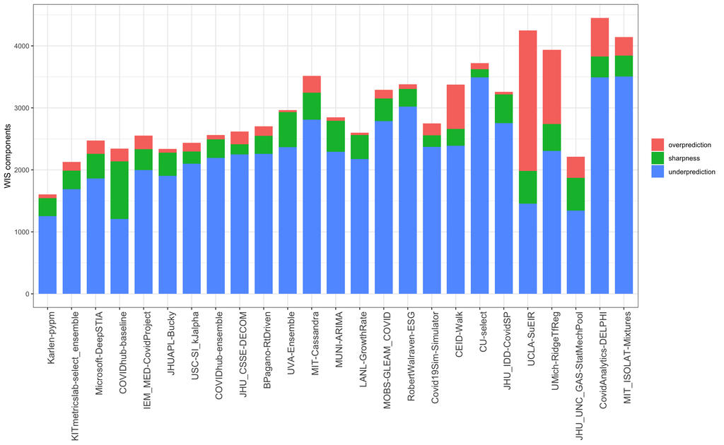

## Evaluation by Week

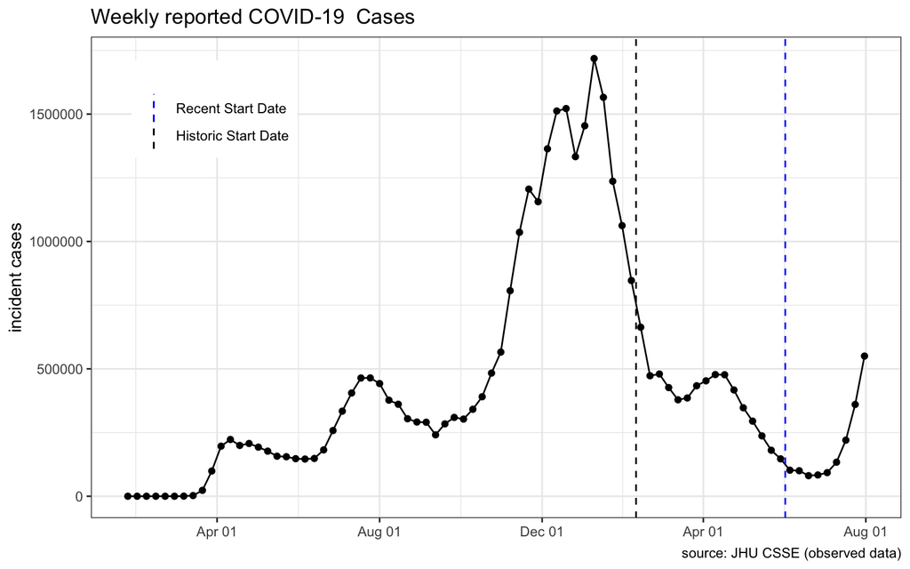

In the following figures, we have evaluated models across multiple forecasting weeks. Points included in this comparison are for models that have submitted probabilistic forecasts for all 50 states.

For the first 2 figures, WIS is used as a metric. The first figure shows the mean WIS across all 50 states for submission weeks beginning February 13, 2021 at a 1 week horizon. The second figure shows the mean WIS aggregated across locations, however it is for a 4 week horizon.

**To view a specific team, double click on the team names in the legend. To view a value on the plot, click on the point in the forecast of interest. To view a specific time of interest, highlight that section on the graph or use the zoom functionality.**

### 1 Week Horizon WIS

[interactive chart not shown]

### 4 Week Horizon WIS

In this figure, the dotted black line represents the average 1 week ahead error across all models. There is often larger error for the 4 week horizon compared to the 1 week horizon.

[interactive chart not shown]

### 1 Week Horizon 95% Coverage

We would expect a well calibrated model to have a value of 95% in this plot.

[interactive chart not shown]

### 4 Week Horizon 95% Coverage

We would expect a well calibrated model to have a value of 95% in this plot. There is typically larger error for the 4 week horizon compared to the 1 week horizon.

[interactive chart not shown]

## Evaluation by location

This figures below show model performance stratified by location. We have only included included models that have submitted forecasts for all 4 horizons and at least 50% of weeks over the past 10 evaluated weeks.

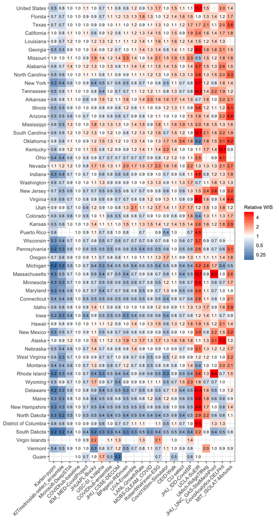

# Incident Death Forecasts

## Summary Tables

The first table below evaluates models based on their [adjusted relative weighted interval scores (WIS, a measure of distributional accuracy)](https://arxiv.org/abs/2005.12881), and adjusted relative mean absolute error (MAE). Scores are aggregated separately for the most recent 10 weeks and for 26 historical weeks. To account for the variation in difficult of forecasting different weeks and locations, a pairwise approach was used to calculated the relative adjusted WIS and MAE. Models with relative scores lower than 1 have been more accurate than the baseline on average, whereas relative scores greater than 1 indicate less accuracy than baseline on average.

The second table evaluates models based on their prediction interval coverage at the 50% and 95% levels. Scores are aggregated seperately for the most recent 10 weeks and for 26 historical weeks.

Inclusion criteria for each column are detailed below the table.

### Accuracy Table

| Model | n recent forecasts | Recent rel WIS | Recent rel MAE | n historical forecasts | Historical rel WIS | Historical rel MAE |
| --- | --- | --- | --- | --- | --- | --- |
| COVIDhub-ensemble | 2052 | 0.43 | 0.52 | 5586 | 0.46 | 0.5 |
| KITmetricslab-select_ensemble | 1872 | 0.43 | 0.53 | 2800 | 0.48 | 0.52 |
| CMU-TimeSeries | 1784 | 0.47 | 0.57 | 5008 | 0.56 | 0.59 |
| Karlen-pypm | 1908 | 0.49 | 0.6 | 5194 | 0.52 | 0.56 |
| SteveMcConnell-CovidComplete | 1872 | 0.49 | 0.57 | 5096 | 0.61 | 0.61 |
| UMass-MechBayes | 2052 | 0.49 | 0.6 | 5586 | 0.49 | 0.52 |
| MOBS-GLEAM_COVID | 1836 | 0.51 | 0.62 | 4998 | 0.56 | 0.59 |
| USC-SI_kJalpha | 2015 | 0.52 | 0.57 | 5487 | 0.63 | 0.59 |
| JHU_CSSE-DECOM | 2052 | 0.54 | 0.65 | 5546 | 0.6 | 0.65 |
| Microsoft-DeepSTIA | 1872 | 0.55 | 0.65 | 4876 | 0.66 | 0.68 |

[output cut: 26 more lines]

In this table, we have included all models with an eligible WIS or MAE score.

In order to meet eligibility for adjusted relative WIS or MAE over the most recent 10 week period, a model must have submitted forecasts 50% or more of the evaluated forecasts in the most recent evaluation period. WIS was only calculated for teams that submitted all required quantiles.

In order to be eligible for the historical calculation of MAE or WIS, a model must have predictions for 50% or more of the evaluated forecasts in the historical evaluation period.

### Coverage Table

For inclusion in this table, a model most have contributed forecasts for 5 or more weeks total since February 13, 2021, or have submitted forecasts during at least 2 out of the last 3 evaluated weeks. This inclusion criteria was applied in order to score models that submitted for a substantial amount of weeks at any point during the pandemic but may no longer be submitting, while also evaluating new teams that have recently joined our forecasting efforts.

| Model | n recent forecasts | Recent 50% coverage | Recent 95% coverage | n historical forecasts | Historical 50% coverage | Historical 95% coverage |
| --- | --- | --- | --- | --- | --- | --- |
| UCSD_NEU-DeepGLEAM | 1836 | 0.96 | 0.99 | 4998 | 0.86 | 0.96 |
| COVIDhub-baseline | 1995 | 0.84 | 0.98 | 5529 | 0.68 | 0.94 |
| CU-select | 1872 | 0.74 | 0.85 | 5096 | 0.54 | 0.72 |
| LNQ-ens1 | 798 | 0.71 | 0.97 | 4332 | 0.73 | 0.97 |
| COVIDhub-ensemble | 2052 | 0.7 | 0.96 | 5586 | 0.64 | 0.94 |
| UA-EpiCovDA | 1908 | 0.68 | 0.92 | 5150 | 0.53 | 0.83 |
| MUNI-ARIMA | 1872 | 0.66 | 0.95 | 2184 | 0.65 | 0.95 |
| UMich-RidgeTfReg | 1782 | 0.6 | 0.96 | 4810 | 0.56 | 0.87 |
| CEID-Walk | 2052 | 0.58 | 0.89 | 5586 | 0.58 | 0.89 |
| CovidAnalytics-DELPHI | 1872 | 0.55 | 0.9 | 5096 | 0.55 | 0.9 |

[output cut: 33 more lines]

## WIS components

The data in this graph has been aggregated over all locations and submission weeks. The models included have submitted forecasts for at least 50% of forecasts out of the last 10 weeks. This is the same exclusion criteria applied for WIS scores in the recent evaluation period.

The sum of the bars adds up to the WIS score. Of note, these values may not be exactly the same as the relative WIS scores shown in the leaderboard table because these are not adjusted for weeks or locations missing.

The data are ordered on the x axis based on their relative WIS score shown in the accuracy table.

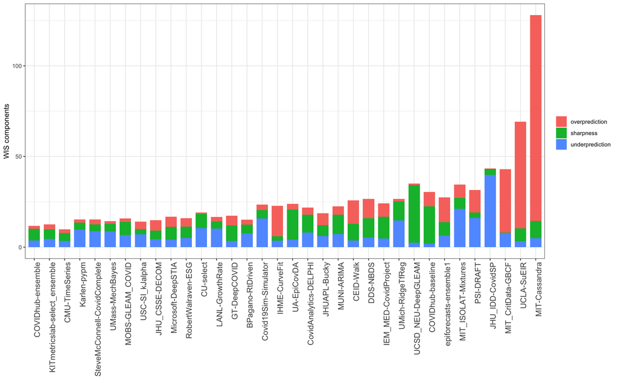

## Evaluation by Week

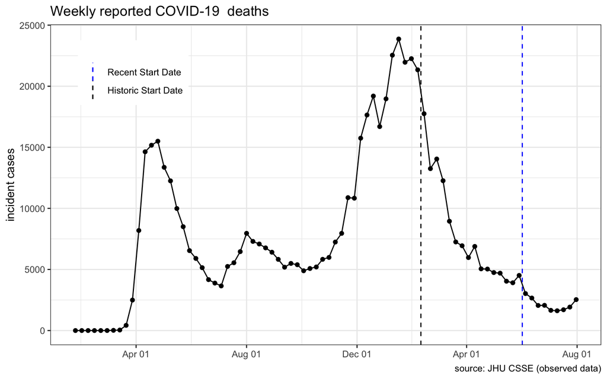

In the following figures, we have evaluated models across multiple forecasting weeks. The models included in this comparison must have submitted forecasts for all 50 states and at a national level for each timepoint.

For the first 2 figures, WIS is used as a metric. The first figure shows the mean WIS across all locations for each submission week at a 1 week horizon. The second figure shows the mean WIS aggregated across locations for a 4 week horizon.

**To view a specific team, double click on the team names in the legend. To view a value on the plot, click on the point in the forecast of interest.To view a specific time of interest, highlight that section on the graph or use the zoom functionality.**

### 1 Week Horizon

[interactive chart not shown]

### 4 Week Horizon WIS

In this figure, the dotted black line represents the average 1 week ahead error across all models. There is often larger error for the 4 week horizon compared to the 1 week horizon.

[interactive chart not shown]

### 1 Week Horizon 95% Coverage

The black line represents 95%

[interactive chart not shown]

### 4 Week Horizon 95% Coverage

The black line represents 95%

[interactive chart not shown]

## Evaluation by location

This figures below show model performance stratified by location In this figure, we only include models that have submitted forecasts for all 4 horizons and at least 50% of the last 10 evaluated weeks.

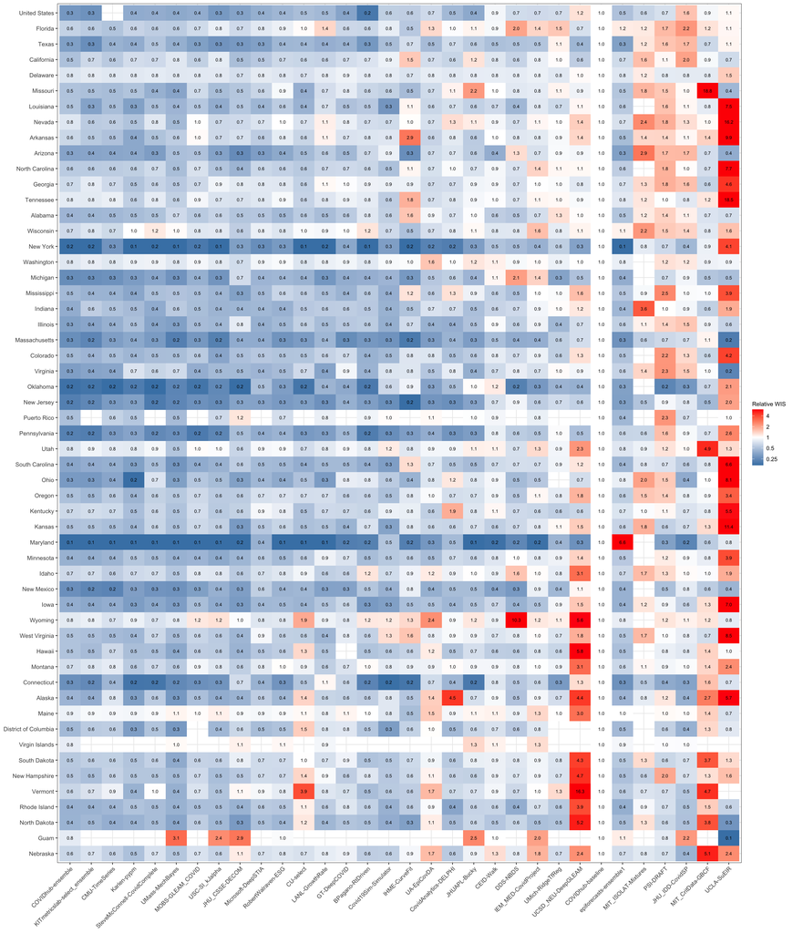